# Лабораторийн ажил 10 - 11

## Classification

Ангилал гэдэг нь бусад атрибутын (урьдчилан таамаглах хувьсагч гэгддэг) утгууд дээр үндэслэн нэрлэсэн (nominal) утгатай атрибутыг (ангиллын шошго гэж нэрлэдэг) таамаглах ажил юм. Энэхүү лабораторийн ажлын хүрээнд:

1. Загварыг хэт тохируулах асуудлыг харуулах.
2. Ангиллын бусад техникүүд
   - K-Nearest neighbor (KNN)
   - Support vector machines (SVM)
   - Ensemble Methods (boosting, bagging, random forest)

## 10.1 Загварын хэт тохируулга

Загвар хэт тохируулагдах асуудлыг харуулахын тулд бид 0 эсвэл 1 гэсэн хоёр ангиллын аль нэгэнд хуваарилагдсан 1500 шошгологдсон тохиолдлуудыг агуулсан хоёр хэмжээст өгөгдлийн багцыг авч үзье. Ангилал бүрээс тохиолдлуудыг дараах байдлаар үүсгэнэ:

- 1-р ангиллын тохиолдлуудыг [6, 14], [10, 6], [14, 14] дээр төвлөрсөн гурван Гауссын тархалтын холимогоос үүсгэсэн.
- 0-р ангиллын тохиолдлуудыг талууд нь 20-той тэнцүү урттай квадрат муж дахь жигд тархалтаас үүсгэсэн.

Хялбар болгохын тулд хоёр ангилал хоёулаа ижил тооны шошгологдсон тохиолдлуудтай (labeled instances). Өгөгдлийг үүсгэх, зурах кодыг доор харуулав. 1-р ангиллын бүх тохиолдлуудыг улаан, 0-р ангиллын тохиолдлуудыг хар өнгөөр харуулсан.

```python
import numpy as np
import matplotlib.pyplot as plt
from numpy.random import random

%matplotlib inline

N = 1500

mean1 = [6, 14]
mean2 = [10, 6]
mean3 = [14, 14]
cov = [[3.5, 0], [0, 3.5]]  # diagonal covariance

np.random.seed(50)
X = np.random.multivariate_normal(mean1, cov, int(N/6))
X = np.concatenate((X, np.random.multivariate_normal(mean2, cov, int(N/6))))
X = np.concatenate((X, np.random.multivariate_normal(mean3, cov, int(N/6))))
X = np.concatenate((X, 20*np.random.rand(int(N/2),2)))
Y = np.concatenate((np.ones(int(N/2)),np.zeros(int(N/2))))
plt.plot(X[:int(N/2),0],X[:int(N/2),1],'r+',X[int(N/2):,0],X[int(N/2):,1],'k.',ms=4)
```

[output not shown]

Энэ жишээнд бид шошготой өгөгдлийн 80%-ийг сургалтанд, үлдсэн 20%-ийг тестэнд зориулна. Дараа нь бид өөр өөр гүнтэй (2-оос 50 хүртэл) шийдвэрийн модыг сургалтын багцыг ашиглан үүсгэж, сургалтын болон тестийн багцад тухайн загварыг хэрэглэх үеийн тэдгээрийн нарийвчлалыг харуулна.

```python
#########################################
# Training and Test set creation
#########################################

from sklearn.model_selection import train_test_split
X_train, X_test, Y_train, Y_test = train_test_split(X, Y, test_size=0.2, random_state=1)

from sklearn import tree
from sklearn.metrics import accuracy_score

#########################################
# Model fitting and evaluation
#########################################

maxdepths = [2,3,4,5,6,7,8,9,10,15,20,25,30,35,40,45,50]

trainAcc = np.zeros(len(maxdepths))
testAcc = np.zeros(len(maxdepths))

index = 0
for depth in maxdepths:
    clf = tree.DecisionTreeClassifier(max_depth=depth)
    clf = clf.fit(X_train, Y_train)
    Y_predTrain = clf.predict(X_train)
    Y_predTest = clf.predict(X_test)
    trainAcc[index] = accuracy_score(Y_train, Y_predTrain)
    testAcc[index] = accuracy_score(Y_test, Y_predTest)
    index += 1

#########################################
# Plot of training and test accuracies
#########################################

plt.plot(maxdepths,trainAcc,'ro-',maxdepths,testAcc,'bv--')
plt.legend(['Training Accuracy','Test Accuracy'])
plt.xlabel('Max depth')
plt.ylabel('Accuracy')
```

[output not shown]

## 10.2 Ангиллын бусад техникүүд

Шийдвэрийн модны ангилагчаас гадна Python sklearn сан нь бусад ангиллын техникүүдийг дэмждэг. Энэ хэсэгт дараах аргуудыг өмнөх хэсэгт (10.1) өгсөн 2 хэмжээст өгөгдөлд хэрхэн ашиглахыг харуулна.

- k-хамгийн ойрын хөршийн ангилагч **(k-nearest neighbor)**
- шугаман ангилагч **(support vector machine)**
- нэгтгэх аргууд **(ensemble methods -- boosting, bagging, random forest)**

### 10.2.1 K-Nearest neighbor ангилагч

Энэ аргын хувьд хамгийн ойрын *k* сургалтын тохиолдлуудын ихэнх нь хамаарч буй ангилалд тулгуурлан тестийн тохиолдлын ангиллын шошгыг урьдчилан таамагладаг. Хамгийн ойрын хөршүүдийн тоо *k* нь зайн хэмжүүрийн хамт хэрэглэгчийн тодорхойлох ёстой гиперпараметр (hyperparameter) болно. Дефаултаар бид Евклидийн зайг ашиглаж болно (энэ нь Минковскийн зайны тухайн тохиолдол буюу p=2 үед Евклидийн зай гэж үздэг):

\begin{equation*} \textrm{Minkowski distance}(x,y) = \bigg[\sum_{i=1}^N |x_i-y_i|^p \bigg]^{\frac{1}{p}} \end{equation*}

```python
from sklearn.neighbors import KNeighborsClassifier
import matplotlib.pyplot as plt
%matplotlib inline

numNeighbors = [1, 5, 10, 15, 20, 25, 30]
trainAcc = []
testAcc = []

for k in numNeighbors:
    clf = KNeighborsClassifier(n_neighbors=k, metric='minkowski', p=2)
    clf.fit(X_train, Y_train)
    Y_predTrain = clf.predict(X_train)
    Y_predTest = clf.predict(X_test)
    trainAcc.append(accuracy_score(Y_train, Y_predTrain))
    testAcc.append(accuracy_score(Y_test, Y_predTest))

plt.plot(numNeighbors, trainAcc, 'ro-', numNeighbors, testAcc,'bv--')
plt.legend(['Training Accuracy','Test Accuracy'])
plt.xlabel('Number of neighbors')
plt.ylabel('Accuracy')
```

[output not shown]

### 10.2.2 Support vector machine (SVM)

Практикт SVM алгоритмыг цөм (kernel) ашиглан хэрэгжүүлдэг. Энэ нь цөмийн трик гэж нэрлэгддэг техникийг ашигладаг. Энгийнээр хэлбэл, цөм нь өгөгдлийг салгах боломжтой илүү өндөр хэмжээс (high dimension) рүү буулгадаг функц юм. Цөм нь бага хэмжээст оролтын өгөгдлийн орон зайг илүү өндөр хэмжээст орон зай болгон хувиргадаг. Тиймээс шугаман бус салгах даалгаврыг шугаман салгах даалгавар болгон хувиргаж, өөр хэмжээсүүдийг нэмдэг. Тиймээс цөмийн энэ арга нь илүү нарийвчлалтай ангилагчийг бий болгоход тусалдаг ба шугаман бус салгах даалгаварт үр дүнтэй байдаг.

SVM-ийн хувьд дараах 4 төрлийн цөмийг нийтлэг хэрэглэдэг.

- Linear kernel
- Polynomial kernel
- Radial Basis Function (RBF) kernel (Gaussian kernel гэж мөн нэрлэгддэг)
- Sigmoid kernel

#### 10.2.2.1 Linear kernel

Шугаман цөмд цөмийн функц нь дараах байдлаар шугаман функцийн хэлбэрийг авдаг.

Шугаман цөм : $K(x_{i}, x_{j}) = x_{i}^{T} x_{j}$

Өгөгдлийг шугаман салгах боломжтой үед шугаман цөмийг ашигладаг. Өөрөөр хэлбэл өгөгдлийг нэг шулуун ашиглан салгаж болно гэсэн үг юм. Энэ нь хамгийн түгээмэл хэрэглэгддэг цөмүүдийн нэг ба өгөгдлийн багцад олон тооны шинж чанарууд байгаа тохиолдолд ихэвчлэн ашиглагддаг. Шугаман цөмийг ихэвчлэн текст ангилах (text classification) зорилгоор ашигладаг.

Шугаман цөм бүхий сургалт нь ихэвчлэн илүү хурдан байдаг, учир нь бид зөвхөн *C* зохицуулалтын параметрийг оновчтой болгох хэрэгтэй. Бусад цөмтэй ажиллахад бид мөн **γ** параметрийг оновчтой болгох хэрэгтэй болдог. Шугаман цөмийг дараах зургаар дүрсэлж болно.

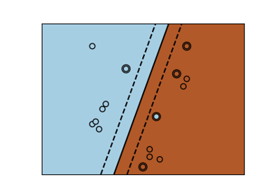

#### 10.2.2.2 Polynomial Kernel

Олон гишүүнт цөм нь анхны хувьсагчийн олон гишүүнт дээрх шинж чанарын орон зай дахь векторуудын (training samples) ижил төстэй байдлыг илэрхийлдэг. Олон гишүүнт цөм нь оролтын түүврийн ижил төстэй байдлыг тодорхойлохын тулд зөвхөн өгөгдсөн шинж чанаруудаас гадна оролтын түүврүүдийн хослолыг авч үздэг. Энэ нь дүрсийн боловсруулалтанд (image processing) түгээмэл хэрэглэгддэг.

*d* зэрэгтэй олон гишүүнтүүдийн хувьд олон гишүүнт цөмийг дараах байдлаар тодорхойлно.

Олон гишүүнт цөм : $K(x_{i}, x_{j}) = (γx_{i}^{T}x_{j} + r)^{d}$

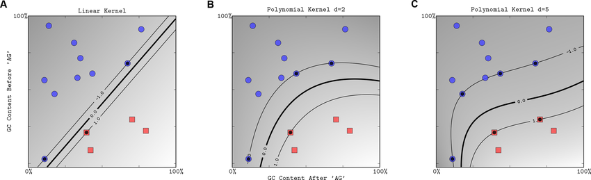

#### 10.2.2.3 Radial Basis Function Kernel

Radial Basis Function цөм нь ерөнхий зориулалттай цөм юм. Өгөгдлийн талаар урьдчилсан мэдлэггүй үед энэ нь ашиглагддаг. x ба y хоёр дээж дээрх RBF цөмийг дараах тэгшитгэлээр тодорхойлно.

$k(x_{i}, x_{j})=exp(-γ||x_{i}-x_{j}||^2), γ > 0$

RBF цөм бүхий SVM ангилал

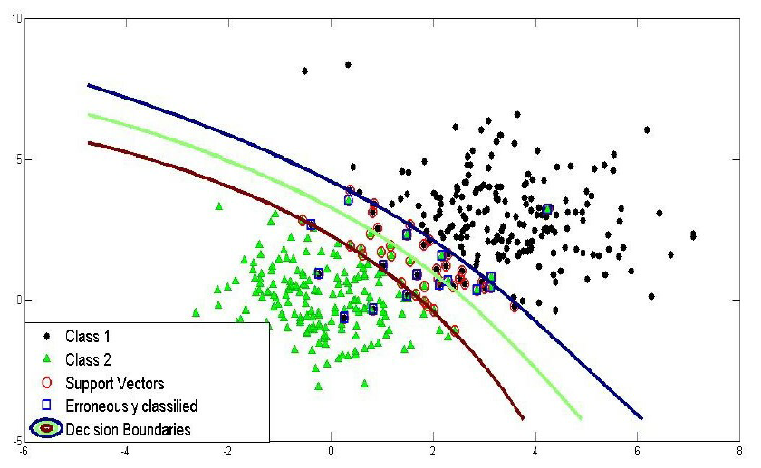

### 10.2.2 (a) Шугаман SVM

*C* параметр нь сургалтын жишээ бүрийг буруу ангилахаас хэр их зайлсхийхийг хүсч байгаагаа SVM оновчлолд (optimization) хэлж өгдөг. *C*-ийн том утгуудын хувьд, сургалтын бүх цэгийг зөв ангилахын тулд жижиг margin бүхий гипер хавтгайг сонгоно. Үүний эсрэгээр, *C*-ийн маш бага утгын хувьд, гипер хавтгай нь олон цэгийг буруу ангилсан ч гэсэн илүү том margin бүхий тусгаарлах гипер хавтгайг хайхад хүргэдэг.

```python
from sklearn.svm import SVC
from sklearn import tree
from sklearn.metrics import accuracy_score

C = [0.01, 0.1, 0.2, 0.5, 0.8, 1, 5, 10, 20, 50]

SVMtrainAcc = []
SVMtestAcc = []

for param in C:
    clf = SVC(C=param,kernel='linear')
    clf.fit(X_train, Y_train)
    Y_predTrain = clf.predict(X_train)
    Y_predTest = clf.predict(X_test)
    SVMtrainAcc.append(accuracy_score(Y_train, Y_predTrain))
    SVMtestAcc.append(accuracy_score(Y_test, Y_predTest))

plt.plot(C, SVMtrainAcc, 'ro-', C, SVMtestAcc,'bv--')
plt.legend(['Training Accuracy','Test Accuracy'])
plt.xlabel('C')
plt.xscale('log')
plt.ylabel('Accuracy')
```

[output not shown]

### 10.2.2 (b) Шугаман бус SVM

```python
from sklearn.svm import SVC

C = [0.01, 0.1, 0.2, 0.5, 0.8, 1, 5, 10, 20, 50]
SVMtrainAcc = []
SVMtestAcc = []

for param in C:
    clf = SVC(C=param,kernel='rbf',gamma='auto')
    clf.fit(X_train, Y_train)
    Y_predTrain = clf.predict(X_train)
    Y_predTest = clf.predict(X_test)
    SVMtrainAcc.append(accuracy_score(Y_train, Y_predTrain))
    SVMtestAcc.append(accuracy_score(Y_test, Y_predTest))

plt.plot(C, SVMtrainAcc, 'ro-', C, SVMtestAcc,'bv--')
plt.legend(['Training Accuracy','Test Accuracy'])
plt.xlabel('C')
plt.xscale('log')
plt.ylabel('Accuracy')
```

[output not shown]

## 10.3 Ensemble methods

Ансамбль ангилагч нь сургалтын өгөгдлөөс үндсэн ангилагчдын багцыг байгуулж, үндсэн ангилагч бүрийн гаргасан таамаглалд санал хураалт явуулж ангиллыг гүйцэтгэдэг. Энэ жишээнд бид 3 төрлийн ансамблийн ангилагчийг авч үзье:

1. bagging
2. boosting
3. random forest

```python
from sklearn import ensemble
from sklearn.tree import DecisionTreeClassifier

numBaseClassifiers = 500
maxdepth = 10
trainAcc = []
testAcc = []

clf = ensemble.RandomForestClassifier(n_estimators=numBaseClassifiers)
clf.fit(X_train, Y_train)
Y_predTrain = clf.predict(X_train)
Y_predTest = clf.predict(X_test)
trainAcc.append(accuracy_score(Y_train, Y_predTrain))
testAcc.append(accuracy_score(Y_test, Y_predTest))

clf = ensemble.BaggingClassifier(base_estimator=DecisionTreeClassifier(max_depth=maxdepth),n_estimators=numBaseClassifiers)
clf.fit(X_train, Y_train)
Y_predTrain = clf.predict(X_train)
Y_predTest = clf.predict(X_test)
trainAcc.append(accuracy_score(Y_train, Y_predTrain))
testAcc.append(accuracy_score(Y_test, Y_predTest))

clf = ensemble.AdaBoostClassifier(base_estimator=DecisionTreeClassifier(max_depth=maxdepth),n_estimators=numBaseClassifiers)
clf.fit(X_train, Y_train)
Y_predTrain = clf.predict(X_train)
Y_predTest = clf.predict(X_test)
trainAcc.append(accuracy_score(Y_train, Y_predTrain))
testAcc.append(accuracy_score(Y_test, Y_predTest))

methods = ['Random Forest', 'Bagging', 'AdaBoost']
fig, (ax1, ax2) = plt.subplots(1, 2, figsize=(12,6))

ax1.bar([1.5,2.5,3.5], trainAcc)
ax1.set_xticks([1.5,2.5,3.5])
ax1.set_xticklabels(methods)

ax2.bar([1.5,2.5,3.5], testAcc)
ax2.set_xticks([1.5,2.5,3.5])
ax2.set_xticklabels(methods)
```

[output not shown]

## 10.5 Дасгал

Чихрийн шижинтэй өвчтөнүүдийг ангилах загваруудыг үүсгэхийн тулд дараах өгөгдлийг ашиглана уу.

DATA: diabetes.csv

**Атрибутууд (Outcome нь зорилтот хувьсагч):**

- Pregnancies
- Glucose
- BloodPressure
- SkinThickness
- Insulin
- BMI (Body mass index)
- DiabetesPedigreeFunction
- Age

**Хийх даалгавар**

1. Өгөгдлийн эхний 5 бичлэгийг хэвлэ.
2. Бүх баганын хувьд статистик утгуудыг хэвлэж хар.
3. Дутуу утга (Missing value) байгаа эсэхийг шалга.
4. Хамгийн их хамааралтай 5 шинж чанаруудыг сонго (correlation matrix).
5. Атрибутуудыг нормчил.
6. Сонгосон хамгийн их хамааралтай атрибутууд дээр outlier байгаа эсэхийг шалгаж, байгаа бол устга.
   - Бидний ашиглаж буй өгөгдлийн хэмжээ бага тул зөвхөн аль нэг атрибутын хувьд outlier устгана уу.
7. Өгөгдлийн багцаас урьдчилан таамаглагч (X) болон зорилтот ангиллын (Y) шинж чанаруудыг гаргаж ав.
8. Өгөгдлийг сургалтын (training set) болон тестийн багц (test set) болгон хуваа.
9. SVM загварыг дараах тохируулгаар сурга. C-н утга хэд байх үед тестийн өгөгдөл дээр хамгийн сайн үр дүнд хүрч байна вэ? Энэ тохиолдлын confusion matrix харуул.

   ```
   C = [50, 10, 1.0, 0.1, 0.01]
   kernel = 'rbf'
   gamma = 'auto'
   ```

10. k-nearest neighbor загварыг хөршийн тоог 1-20 утгууд дээр сурга. k-н ямар утганд тестийн өгөгдөлд хамгийн сайн үр дүнд хүрч байна вэ?
11. Нэгтгэх аргуудыг ашиглан загварыг сургаж, тестийн өгөгдөл дээрх нарийвчлалыг тооц. Арга тус бүр дээр дараах байдлаар үндсэн ангиллын загварыг сонго.
    - random forest: desicion tree
    - bagging: KNN, (10)-р даалгавар дээр хамгийн сайн үр дүнд хүрсэн k-н утгыг ашигла.
    - boosting: SVM, svm ангилагч дээр обьект үүсгэхдээ **probability=True** параметрийг тодорхойлохыг анхаарна уу.
12. Энэхүү өгөгдөл дээр сургасан аль арга тестийн өгөгдөл дээр хамгийн сайн үр дүнд хүрсэн бэ?